# Visualisation Documentation

*Version:* `1.2` *(Jupytext, time measurements, logger, param notebook execution, fixes)*

# Table of Content

- Notebook Description
- General Settings
  - Paths
  - Notebook Functionality and Appearance
  - External Libraries
  - Internal Code
  - Constants
- Visualizations Examples
  - Histogram
  - Bar Chart
    - Bar Chart Sorted by Values
    - Bar Chart Sorted by IDs
  - Time Series Visualizations
    - Selectors
    - Time Series
      - One Time Series
      - Multiple Series
      - Filling
      - Anomalies
      - Vertical Lines Positions
    - Time Series Events
      - Simple Plot
      - Full Plot
    - Candle Plot
      - Candle Plot
      - Candle Plot with Series
      - Candle Plot with Series and Events
      - Candle Plot with Series and Events and Vertical Lines
  - Multi Histogram - Distplot
  - Multi Histogram
  - Line Plot
  - 2D Histogram (Density Heatmap)
    - Basic 2D Histogram
    - 2D Histogram with Custom Colorscale
    - 2D Histogram with Square Aspect Ratio
  - Heatmap
    - Basic Heatmap
    - Heatmap with Custom Colorscale
    - Correlation Matrix
  - Multi Bar Chart
    - Grouped Bar Chart
    - Stacked Bar Chart
    - Multi Bar Chart Sorted by Specific Series
- Overall Customisation
  - Size of the Picture
  - Colours
  - Other Params Settings
- Final Timestamp

# Notebook Description

ToC

This notebook serves as a documentation notebook for visualisation code from *src\visualisations*.

# GENERAL SETTINGS

ToC

General settings for the notebook (paths, python libraries, own code, notebook constants).

> *NOTE: All imports and constants for the notebook settings shoud be here. Nothing should be imported in the analysis section.*

### Paths

ToC

Adding paths that are necessary to import code from within the repository.

```python
import sys
import os
sys.path+=[os.path.join(os.getcwd(), ".."), os.path.join(os.getcwd(), "../..")] # one and two up
```

### Notebook Functionality and Appearance

ToC Necessary libraries for notebook functionality:

- A button for hiding/showing the code. By default it is deactivated and can be activated by setting CREATE_BUTTON constant to True.

> **NOTE: This way, using the function, the button works only in active notebook. If the functionality needs to be preserved in html export, then the code has to be incluced directly into notebook.**
- Set notebook width to 100%.
- Notebook data frame setting for better visibility.
- Initial timestamp setting and logging the start of the execution.

#### Overall Setting Specification

```python
LOGGER_CONFIG_NAME = "logger_file_limit_console"
ADDAPT_WIDTH = False
```

#### Overall Behaviour Setting

```python
try:
    from src.utils.notebook_support_functions import create_button, get_notebook_name
    NOTEBOOK_NAME = get_notebook_name()
    SUPPORT_FUNCTIONS_READ = True
except:
    NOTEBOOK_NAME = "NO_NAME"
    SUPPORT_FUNCTIONS_READ = False
```

[output not shown]

```python
from src.utils.logger import Logger
from src.utils.envs import Envs
from src.utils.config import Config
from pandas import options
from IPython.display import display, HTML
```

```python
options.display.max_rows = 500
options.display.max_columns = 500
envs = Envs()
envs.set_logger(LOGGER_CONFIG_NAME)
Logger().start_timer(f"NOTEBOOK; Notebook name: {NOTEBOOK_NAME}")
if ADDAPT_WIDTH:
    display(HTML("<style>.container { width:100% !important; }</style>")) # notebook width
```

[output not shown]

```python
# create_button()
```

### External Libraries

ToC

```python
from datetime import datetime
from importlib import reload
from pandas import Series, options, DataFrame
from numpy.random import seed, normal, randint
from numpy import array, log
from numpy.random import randn
from datetime import datetime
```

### Internal Code

ToC Code, libraries, classes, functions from within the repository.

```python
from src.utils.date_time_functions import create_datetime_id
from src.visualisations.visualisation_functions import create_time_series
```

### Constants

ToC Constants for the notebook.

> *NOTE: Please use all letters upper.*

#### General Constants

ToC

```python
# from src.global_constants import *  # Remember to import only the constants in use
N_ROWS_TO_DISPLAY = 2
FIGURE_SIZE_SETTING = {"autosize": False, "width": 2200, "height": 750}
```

#### Constants for Setting Automatic Run

ToC

```python
# MANDATORY FOR CONFIG DEFINITION AND NOTEBOOK AND ITS OUTPUTS IDENTIFICATION #########################################
PYTHON_CONFIG_NAME = "python_local"
ID = create_datetime_id(now=datetime.now(), add_micro=False)
# (END) MANDATORY FOR CONFIG DEFINITION AND NOTEBOOK AND ITS OUTPUTS IDENTIFICATION ###################################
```

#### Python Config Initialisation

ToC

```python
envs.set_config(PYTHON_CONFIG_NAME)
```

#### Notebook Specific Constants

ToC

```python
from src.data.attributes import A
```

```python
ATTR_OPEN = "OPEN"
ATTR_HIGH = "HIGHT"
ATTR_LOW = "LOW"
ATTR_CLOSE = "CLOSE"
```

# Visualizations Examples

ToC

## Histogram

ToC

```python
seed(185)

data = normal(size=500)
print(f"Type of the data is: {type(data)}")
print(f"Several observations: {data[0:10]}")

plot_title = "My Super Random Histogram"
x_title = "Awesome Random Data"
```

```
Type of the data is: <class 'numpy.ndarray'>
Several observations: [ 0.04471179 -1.09776817  1.63620698 -1.12098251 -0.93842551 -0.71691279
  0.77317168  0.31091126  0.67555112  1.00791911]
```

### Plane Histogram

ToC

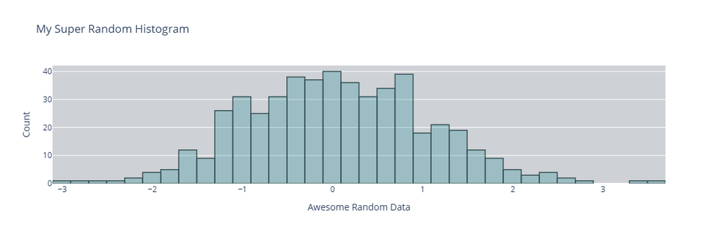

```python
import src.visualisations.plotly_histogram as HIST

reload(HIST)

histogram = HIST.PlotlyHistogram()

histogram.plot(data=data, plot_title=plot_title, x_title=x_title)
```

### Number of Bins

ToC

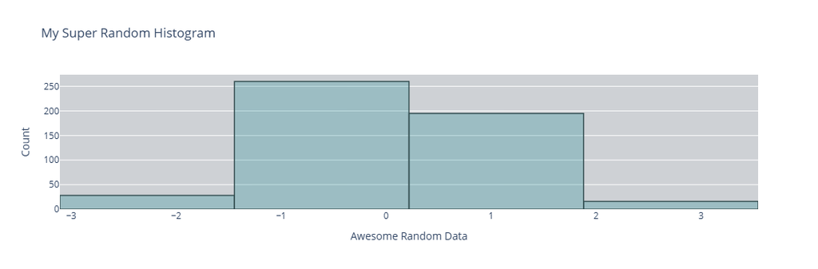

```python
import src.visualisations.plotly_histogram as HIST

reload(HIST)

histogram = HIST.PlotlyHistogram()

histogram.plot(data=data, plot_title=plot_title, x_title=x_title, n_bins=4)
```

### Setting the X-axis Range

ToC

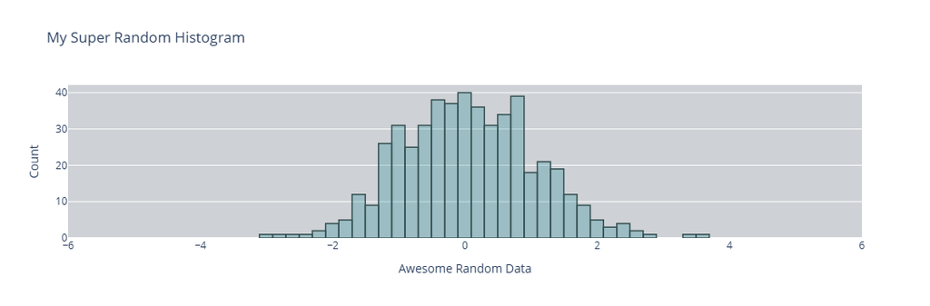

```python
import src.visualisations.plotly_histogram as HIST

reload(HIST)

histogram = HIST.PlotlyHistogram()

histogram.plot(data=data, plot_title=plot_title, x_title=x_title, n_bins=0, x_axis_min_max=(-6, 6))
```

### Set Vertical Line

ToC

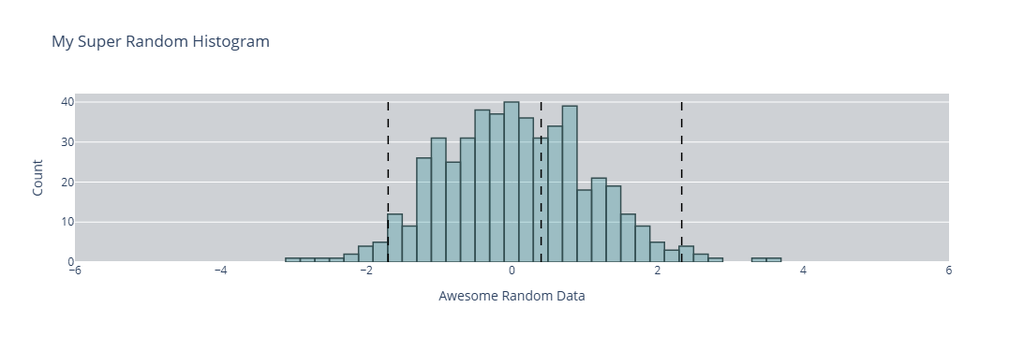

```python
import src.visualisations.plotly_histogram as HIST

reload(HIST)

histogram = HIST.PlotlyHistogram()

histogram.plot(data=data, plot_title=plot_title, x_title=x_title, n_bins=0, x_axis_min_max=(-6, 6),
               vertical_lines_positions=[-1.7, 0.4, 2.33])
```

## Bar Chart

ToC

## Bar Chart Sorted by Values

ToC

```python
array_id = array(["Alpha", "Beta", "Gamma"])
array_values = array([10, 5, 30])
plot_title = "Super Bar Chart"
name_id = "Greek Alphabet"
name_values = "Occurance"

order_by_values = True
reverse = True
```

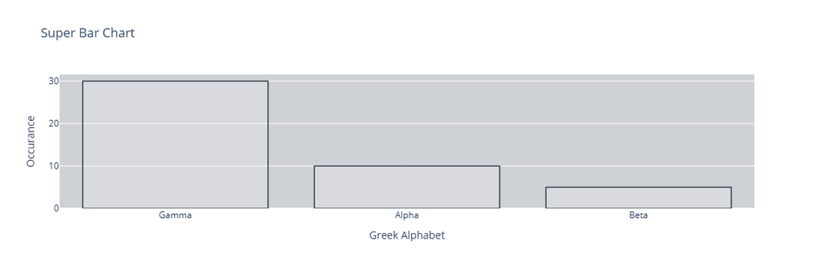

```python
import src.visualisations.plotly_bar_chart as BAR

reload(BAR)

bar_chart = BAR.PlotlyBarChart()

bar_chart.plot(array_id, array_values, plot_title, name_id, name_values, order_by_values, reverse)
```

## Bar Chart Sorted by IDs

ToC

```python
array_id = array(["Alpha", "Beta", "Gamma"])
array_values = array([10, 5, 30])
plot_title = "Super Bar Chart"
name_id = "Greek Alphabet"
name_values = "Occurance"

order_by_values = False
reverse = False
```

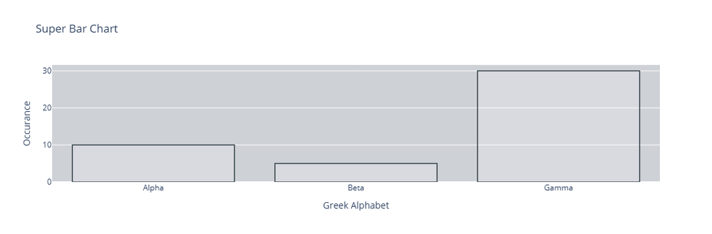

```python
import src.visualisations.plotly_bar_chart as BAR

reload(BAR)

bar_chart = BAR.PlotlyBarChart()

bar_chart.plot(array_id, array_values, plot_title, name_id, name_values, order_by_values, reverse)
```

```python
array_id = array([3, 2, 4, 1])
array_values = array([10, 5, 7, 30])
plot_title = "Super Bar Chart"
name_id = "Greek Alphabet"
name_values = "Occurance"

order_by_values = False
```

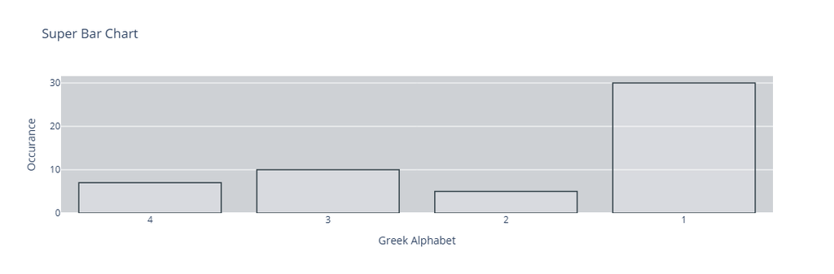

```python
import src.visualisations.plotly_bar_chart as BAR

reload(BAR)

bar_chart = BAR.PlotlyBarChart()

bar_chart.plot(array_id, array_values, plot_title, name_id, name_values, order_by_values)
```

## Time Series Visualization

ToC

```python
ts_1 = create_time_series(seed_number=11, x_multiplier=0.3)
ts_1_names = [f"Amazing Data {i}" for i in range(1, len(ts_1)+1)]
ts_2 = create_time_series(seed_number=32, x_multiplier=1.1)
ts_2_names = [f"Random Data {i}" for i in range(1, len(ts_2)+1)]
ts_3 = create_time_series(seed_number=64, x_multiplier=1.8)
ts_3_names = [f"Third TS {i}" for i in range(1, len(ts_3)+1)]

# ts_4 = create_time_series(seed_number=20, x_multiplier=0.7)
# ts_5 = create_time_series(seed_number=87, x_multiplier=0.1)
# ts_6 = create_time_series(seed_number=63, x_multiplier=2.5)

print(type(ts_1))
print(type(ts_1.iloc[0]))
print(type(ts_1.index))
print("\n")
print(ts_1.head())

plot_title = "Awesome Random Time Series Plot"
y_title = "Awesome Random Data"
```

```
<class 'pandas.Series'>
<class 'numpy.float64'>
<class 'pandas.DatetimeIndex'>


2020-01-01    15.034193
2020-01-02    17.837349
2020-01-03    19.047933
2020-01-04    18.406327
2020-01-05    19.362226
dtype: float64
```

### Selectors

ToC

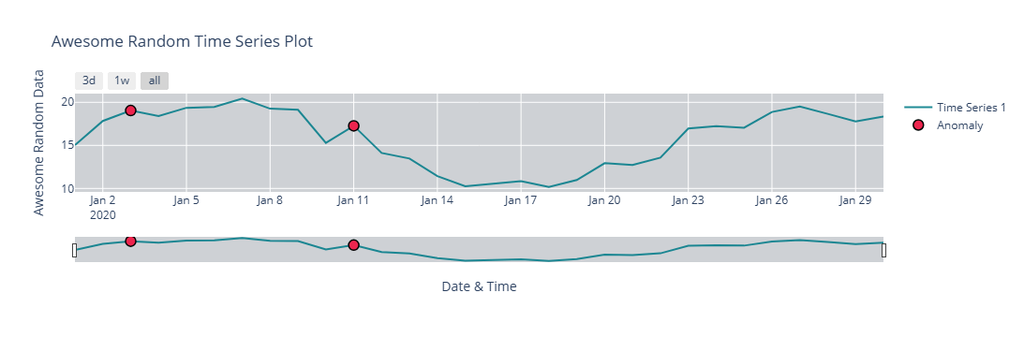

```python
import src.visualisations.plotly_time_series as TS

reload(TS)

ts_vizu_selectors = TS.PlotlyTimeSeries()

ts_vizu_selectors.set_selectors(selectors=[
    {"count": 3, "label": "3d", "step": "day", "stepmode": "backward"},
    {"count": 7, "label": "1w", "step": "day", "stepmode": "backward"},
    {"step": "all"}
])

ts_vizu_selectors.plot(
    series=[ts_1],
    anomalies=[2, 10],
    plot_title=plot_title,
    y_title=y_title
)
```

### Time Series

ToC

#### One Time Series

ToC

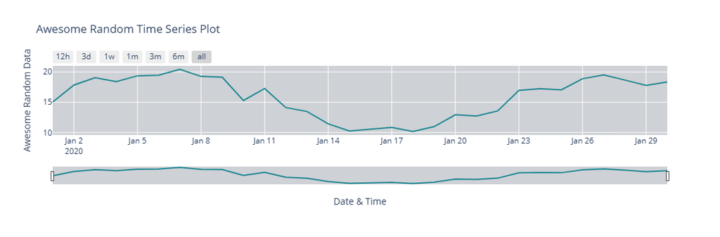

```python
import src.visualisations.plotly_time_series as TS

reload(TS)

ts_visu = TS.PlotlyTimeSeries()

ts_visu.plot(
    series=[ts_1],
    plot_title=plot_title,
    y_title=y_title
)
```

#### Multiple Series

ToC

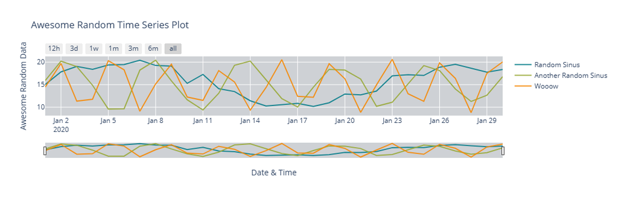

```python
import src.visualisations.plotly_time_series as TS

reload(TS)

ts_visu = TS.PlotlyTimeSeries()

ts_visu.plot(
    series=[ts_1, ts_2, ts_3],
    series_names=["Random Sinus", "Another Random Sinus", "Wooow"],
    series_obs_names=[ts_1_names, ts_2_names, ts_3_names],
    plot_title=plot_title,
    y_title=y_title
)
```

#### Filling

ToC

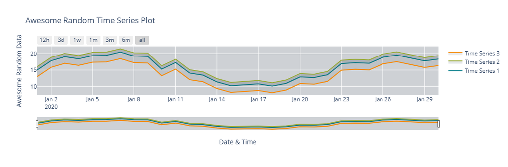

```python
import src.visualisations.plotly_time_series as TS

reload(TS)

ts_visu = TS.PlotlyTimeSeries()

ts_visu.plot(
    series=[ts_1, ts_1+1, ts_1-2],
    plot_title=plot_title,
    y_title=y_title,
    fill_areas=True
)
```

#### Anomalies

ToC

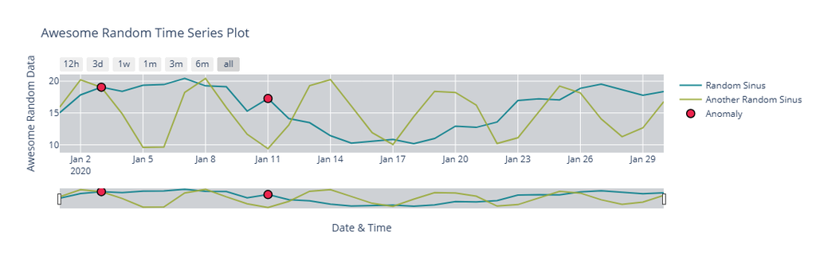

```python
import src.visualisations.plotly_time_series as TS

reload(TS)

ts_visu = TS.PlotlyTimeSeries()

ts_visu.plot(
    series=[ts_1, ts_2],
    series_names=["Random Sinus", "Another Random Sinus"],
    series_obs_names=[ts_1_names, ts_2_names],
    anomalies=[2, 10],
    anomalies_obs_names=["False", "Perfect"],
    plot_title=plot_title,
    y_title=y_title
)
```

#### Vertical Lines Positions

ToC

```python
vertical_lines_positions = [ts_1.index[3], ts_1.index[12]]
```

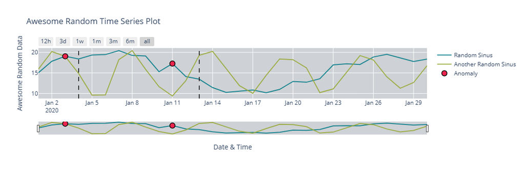

```python
import src.visualisations.plotly_time_series as TS

reload(TS)

ts_visu = TS.PlotlyTimeSeries()

ts_visu.plot(
    series=[ts_1, ts_2],
    series_names=["Random Sinus", "Another Random Sinus"],
    series_obs_names=[ts_1_names, ts_2_names],
    anomalies=[2, 10],
    anomalies_obs_names=["False", "Perfect"],
    plot_title=plot_title,
    y_title=y_title,
    vertical_lines_positions=vertical_lines_positions
)
```

### Time Series Events

ToC

```python
ts_1 = create_time_series(seed_number=11, x_multiplier=0.3)
ts_1_names = [f"Amazing Data {i}" for i in range(1, len(ts_1)+1)]
ts_2 = create_time_series(seed_number=32, x_multiplier=1.1)
ts_2_names = [f"Random Data {i}" for i in range(1, len(ts_2)+1)]

buys = ts_1.iloc[[1, 9, 10, 12, 13, 14],]
buy_names = [f"Buy {i+1}" for i, _ in enumerate(buys)]
sells = ts_1.iloc[[4, 17, 20, 22, 26],]
sell_names = [f"Sell {i+1}" for i, _ in enumerate(sells)]

print(type(ts_1))
print(type(ts_1.iloc[0]))
print(type(ts_1.index))
print("\n")
print(ts_1.head())

plot_title = "Awesome Random Time Series Plot"
y_title = "Awesome Random Data"
```

```
<class 'pandas.Series'>
<class 'numpy.float64'>
<class 'pandas.DatetimeIndex'>


2020-01-01    15.034193
2020-01-02    17.837349
2020-01-03    19.047933
2020-01-04    18.406327
2020-01-05    19.362226
dtype: float64
```

#### Simple Plot

ToC

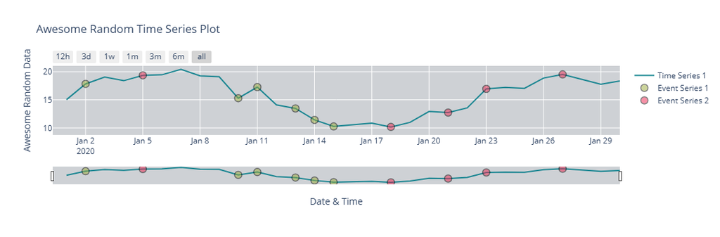

```python
import src.visualisations.plotly_time_series_events as TS

reload(TS)

ts_visu = TS.PlotlyTimeSeriesEvents()

ts_visu.plot(
    series=[ts_1],
    events=[buys, sells],
    plot_title=plot_title,
    y_title=y_title
)
```

#### Full Plot

ToC

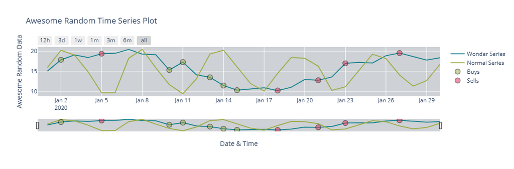

```python
import src.visualisations.plotly_time_series_events as TS

reload(TS)

ts_visu = TS.PlotlyTimeSeriesEvents()

ts_visu.plot(
    series=[ts_1, ts_2],
    series_names=["Wonder Series", "Normal Series"],
    series_obs_names=[ts_1_names, ts_2_names],
    events=[buys, sells],
    event_names=["Buys", "Sells"],
    event_obs_names=[buy_names, sell_names],
    plot_title=plot_title,
    y_title=y_title,
)
```

### Candle Plot

ToC

```python
df_1 = DataFrame(create_time_series(seed_number=11, x_multiplier=0.3))
df_1.rename(columns={0: ATTR_OPEN}, inplace=True)
df_1[ATTR_HIGH] = create_time_series(seed_number=7651, x_multiplier=0.2)
df_1[ATTR_LOW] = create_time_series(seed_number=751, x_multiplier=0.4)
df_1[ATTR_CLOSE] = create_time_series(seed_number=76, x_multiplier=0.1)
df_1.head(2)
```

|  | OPEN | HIGHT | LOW | CLOSE |
| --- | --- | --- | --- | --- |
| 2020-01-01 | 15.034193 | 14.904483 | 15.101097 | 14.429313 |
| 2020-01-02 | 17.837349 | 15.141282 | 16.820972 | 17.249997 |

```python
ts_1 = create_time_series(seed_number=11, x_multiplier=0.3)
ts_1_names = [f"Amazing Data {i}" for i in range(1, len(ts_1)+1)]
ts_2 = create_time_series(seed_number=32, x_multiplier=1.1)
ts_2_names = [f"Random Data {i}" for i in range(1, len(ts_2)+1)]
```

```python
buy_series = df_1["CLOSE"].iloc[[1, 27]]
buy_series_names = ["Good Buy", "Bad Buy"]
sell_series = df_1["CLOSE"].iloc[[6, 16]]
sell_series_names = ["So So Sell", "Wooow Sell"]
third_series = df_1[ATTR_HIGH].iloc[[10, 20]]
third_series_names = ["Test", "Next Test"]
```

```python
plot_title = "Awesome Random Time Series Plot"
y_title = "Awesome Random Data"
```

#### Candle Plot

ToC

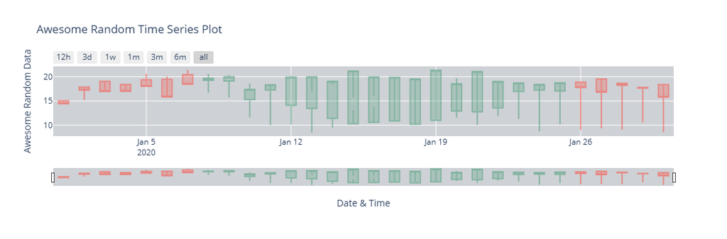

```python
import src.visualisations.plotly_candle as PC

reload(PC)

candle_visu = PC.PlotlyCandle()

candle_visu.plot(
    df_market=df_1,
    plot_title=plot_title,
    y_title=y_title
)
```

#### Candle Plot with Series

ToC

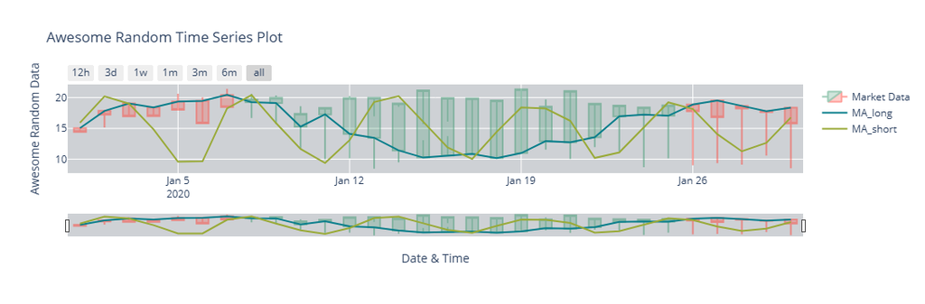

```python
import src.visualisations.plotly_candle as PC

reload(PC)

candle_visu = PC.PlotlyCandle()

candle_visu.plot(
    df_market=df_1,
    series=[ts_1, ts_2],
    series_names=["MA_long", "MA_short"],
    series_obs_names=[ts_1_names, ts_2_names],
    plot_title=plot_title,
    y_title=y_title
)
```

#### Candle Plot with Series and Events

ToC

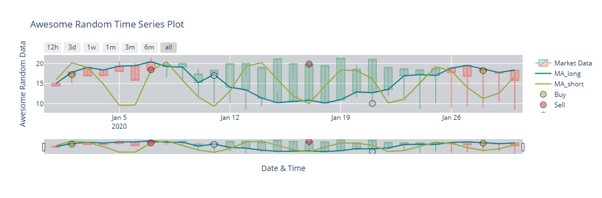

```python
import src.visualisations.plotly_candle as PC

reload(PC)

candle_visu = PC.PlotlyCandle()

candle_visu.plot(
    df_market=df_1,
    series=[ts_1, ts_2],
    series_names=["MA_long", "MA_short"],
    series_obs_names=[ts_1_names, ts_2_names],
    events=[buy_series, sell_series, third_series],
    event_names=["Buy", "Sell", "Third"],
    event_obs_names=[buy_series_names, sell_series_names, third_series_names],
    plot_title=plot_title,
    y_title=y_title
)
```

#### Candle Plot with Series and Events and Vertical Lines

ToC

```python
datetime(2020, 1, 12)
```

```
datetime.datetime(2020, 1, 12, 0, 0)
```

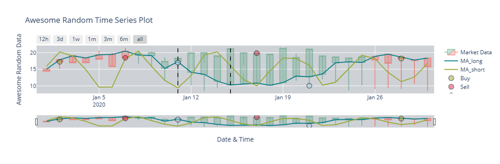

```python
import src.visualisations.plotly_candle as PC

reload(PC)

candle_visu = PC.PlotlyCandle()

candle_visu.plot(
    df_market=df_1,
    series=[ts_1, ts_2],
    series_names=["MA_long", "MA_short"],
    series_obs_names=[ts_1_names, ts_2_names],
    events=[buy_series, sell_series, third_series],
    event_names=["Buy", "Sell", "Third"],
    event_obs_names=[buy_series_names, sell_series_names, third_series_names],
    vertical_lines_positions=[df_1.index[10], datetime(2020, 1, 15)],
    plot_title=plot_title,
    y_title=y_title
)
```

## Multi Histogram - Distplot

ToC

```python
n = 100

x1 = randn(n)-2
x2 = randn(n+20)
x3 = randn(n+100)+2
x4 = randn(n+200)+4
x5 = randn(n+200)+6
x6 = randn(n+200)+8

data = [x1, x2, x3, x4, x5, x6]

group_labels = ["My Group 1", "My Group 2", "My Group 3", "My Group 4", "My Group 5", "My Group 6"]
bin_size = [0.1, 0.25, 0.5, 1, 0.125, 0.75]

plot_title = "My Super Random Histogram"
x_title = "Awesome Random Data"
```

### Basic Distplot

ToC

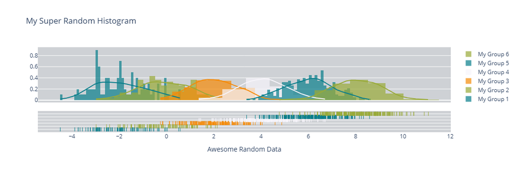

```python
import src.visualisations.plotly_histogram_distplot as HIST_DIST

reload(HIST_DIST)

histogram_distplot = HIST_DIST.PlotlyHistogramDistplot()

histogram_distplot.plot(data=data, plot_title=plot_title, x_title=x_title, group_labels=group_labels, bin_size=bin_size,
                     x_axis_min_max=None, vertical_lines_positions=None, dashboard=False)
```

### Displot with Range

ToC

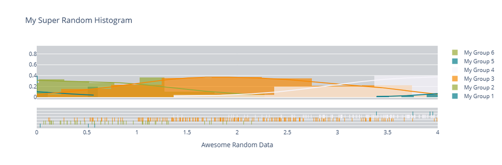

```python
import src.visualisations.plotly_histogram_distplot as HIST_DIST

reload(HIST_DIST)

histogram_distplot = HIST_DIST.PlotlyHistogramDistplot()

histogram_distplot.plot(data=data, plot_title=plot_title, x_title=x_title, group_labels=group_labels, bin_size=bin_size,
                     x_axis_min_max=[0, 4], vertical_lines_positions=None, dashboard=False)
```

### Distplot with Lines

ToC

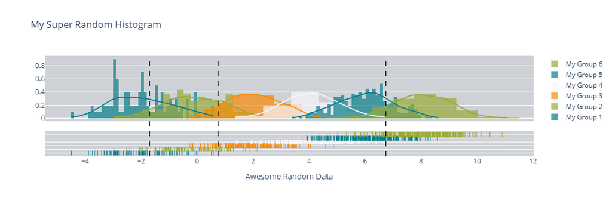

```python
import src.visualisations.plotly_histogram_distplot as HIST_DIST

reload(HIST_DIST)

histogram_distplot = HIST_DIST.PlotlyHistogramDistplot()

histogram_distplot.plot(data=data, plot_title=plot_title, x_title=x_title, group_labels=group_labels, bin_size=bin_size,
                     x_axis_min_max=None, vertical_lines_positions=[-1.7, 0.75, 6.74], dashboard=False)
```

## Multi Histogram

ToC

```python
n = 100

x1 = randn(n)-2
x2 = randn(n+20)
x3 = randn(n+100)+2
x4 = randn(n+200)+4
x5 = randn(n+200)+6
x6 = randn(n+200)+8

data = [x1, x2, x3, x4, x5, x6]

group_labels = ["My Group 1", "My Group 2", "My Group 3", "My Group 4", "My Group 5", "My Group 6"]

plot_title = "My Super Random Histogram"
x_title = "Awesome Random Data"
```

### Basic Multi Histogram

ToC

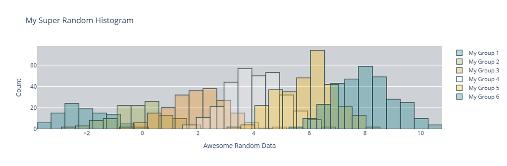

```python
import src.visualisations.plotly_histogram_multi as HIST_MULTI

reload(HIST_MULTI)

histogram_multi = HIST_MULTI.PlotlyHistogramMulti()

histogram_multi.plot(data=data, plot_title=plot_title, x_title=x_title, group_labels=group_labels)
```

### Full Version

ToC

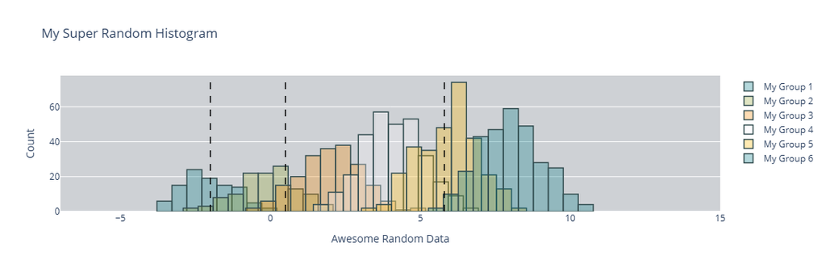

```python
import src.visualisations.plotly_histogram_multi as HIST_MULTI

reload(HIST_MULTI)

histogram_multi = HIST_MULTI.PlotlyHistogramMulti()

histogram_multi.plot(data=data, plot_title=plot_title, x_title=x_title, group_labels=group_labels,
                    x_axis_min_max=(-7, 15), vertical_lines_positions=[-2, 0.5, 5.8])
```

## Line Plot

ToC

```python
x_list = list(range(1, 26))
x = array(x_list)
y_1 = array([0.5 * x for x in x_list])
y_2 = array([log(x) for x in x_list])
x_short = array(list(range(5, 16)))
y_short = x_short * 2
```

```python
line_names = ["Linear", "Logarithm", "Shorter Line"]
plot_title = "Line Chart"
x_title = "X Values"
y_title = "Y Values"
```

### Basic Version

ToC

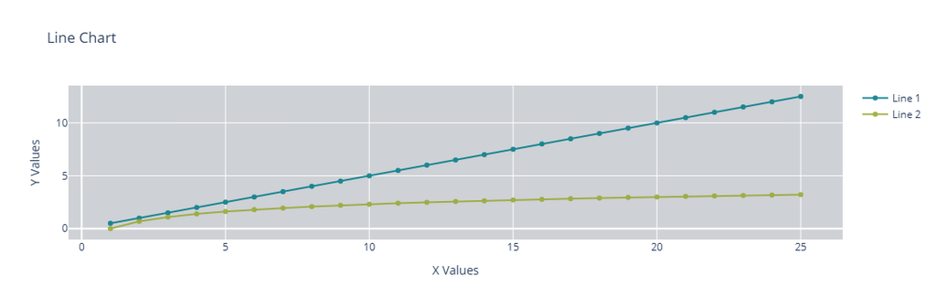

```python
import src.visualisations.plotly_line_chart as LINE

reload(LINE)

line_chart = LINE.PlotlyLineChart()

line_chart.plot(lines=[(x, y_1), (x, y_2)], plot_title=plot_title, x_title=x_title, y_title=y_title)
```

### Full Version

ToC

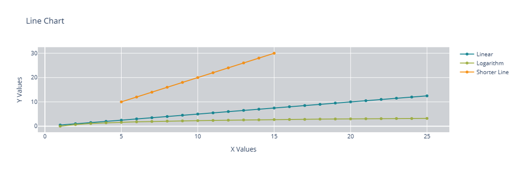

```python
import src.visualisations.plotly_line_chart as LINE

reload(LINE)

line_chart = LINE.PlotlyLineChart()

line_chart.plot(lines=[(x, y_1), (x, y_2), (x_short, y_short)], line_names=line_names, plot_title=plot_title, x_title=x_title, y_title=y_title)
```

## 2D Histogram (Density Heatmap)

ToC

2D histograms are useful for visualizing density distributions in 2D spaces, particularly for latent space visualization.

```python
from numpy import histogram2d, linspace

# Generate sample 2D data
seed(42)
x_data = normal(loc=0, scale=1, size=1000)
y_data = normal(loc=0, scale=1.5, size=1000)

# Create 2D histogram
hist, x_edges, y_edges = histogram2d(x_data, y_data, bins=30)

plot_title = "2D Density Distribution"
x_title = "X Dimension"
y_title = "Y Dimension"
```

### Basic 2D Histogram

ToC

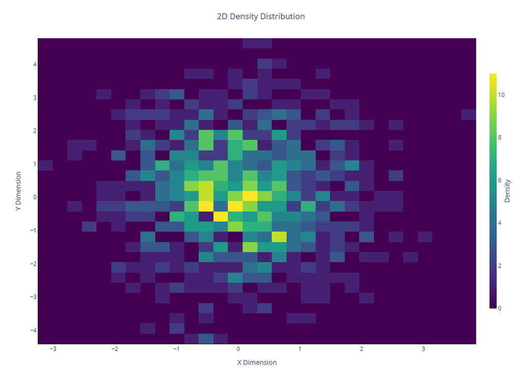

```python
import src.visualisations.plotly_histogram_2d as HIST2D

reload(HIST2D)

histogram_2d = HIST2D.PlotlyHistogram2D()

histogram_2d.plot(hist=hist, x_edges=x_edges, y_edges=y_edges, plot_title=plot_title,
                  x_title=x_title, y_title=y_title)
```

### 2D Histogram with Custom Colorscale

ToC

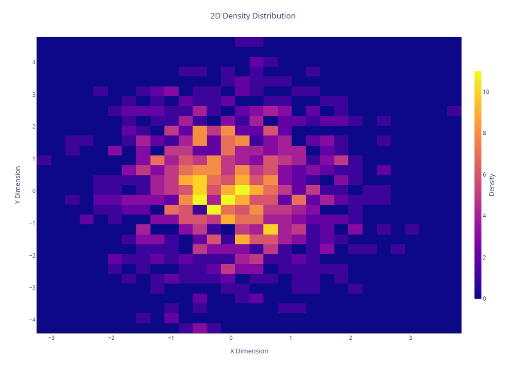

```python
import src.visualisations.plotly_histogram_2d as HIST2D

reload(HIST2D)

histogram_2d = HIST2D.PlotlyHistogram2D()

histogram_2d.plot(hist=hist, x_edges=x_edges, y_edges=y_edges, plot_title=plot_title,
                  x_title=x_title, y_title=y_title, colorscale="Plasma")
```

### 2D Histogram with Square Aspect Ratio

ToC

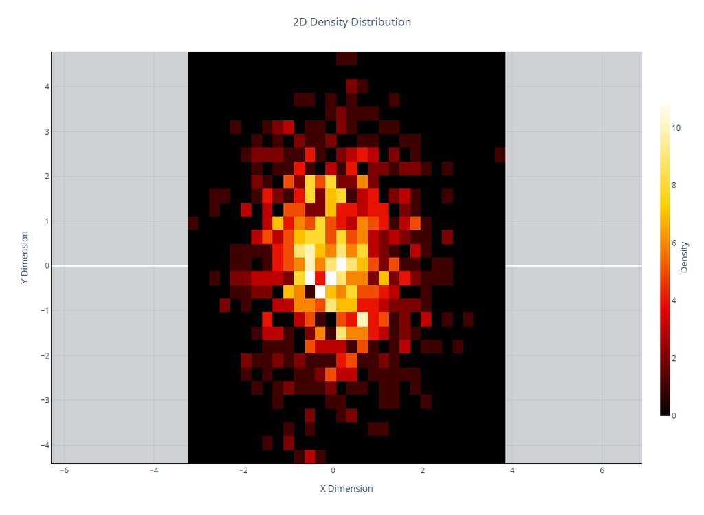

```python
import src.visualisations.plotly_histogram_2d as HIST2D

reload(HIST2D)

histogram_2d = HIST2D.PlotlyHistogram2D()

histogram_2d.plot(hist=hist, x_edges=x_edges, y_edges=y_edges, plot_title=plot_title,
                  x_title=x_title, y_title=y_title, colorscale="Hot", square=True)
```

## Heatmap

ToC

Heatmaps are particularly useful for visualizing correlation matrices and other 2D data.

```python
# Generate sample correlation matrix
seed(123)
n_features = 5
random_data = randn(100, n_features)
corr_df = DataFrame(random_data, columns=[f"Feature_{i+1}" for i in range(n_features)])
correlation_matrix = corr_df.corr()

print("Correlation Matrix:")
print(correlation_matrix)
```

```
Correlation Matrix:
           Feature_1  Feature_2  Feature_3  Feature_4  Feature_5
Feature_1   1.000000   0.000564   0.043562   0.235449   0.053101
Feature_2   0.000564   1.000000   0.025411  -0.003014   0.111698
Feature_3   0.043562   0.025411   1.000000   0.060992  -0.077252
Feature_4   0.235449  -0.003014   0.060992   1.000000   0.079848
Feature_5   0.053101   0.111698  -0.077252   0.079848   1.000000
```

### Basic Heatmap

ToC

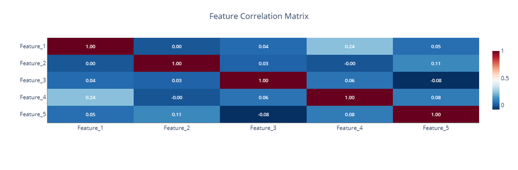

```python
import src.visualisations.plotly_heatmap as HMAP

reload(HMAP)

heatmap = HMAP.PlotlyHeatmap()

heatmap.plot(data=correlation_matrix, plot_title="Feature Correlation Matrix")
```

### Heatmap with Custom Colorscale

ToC

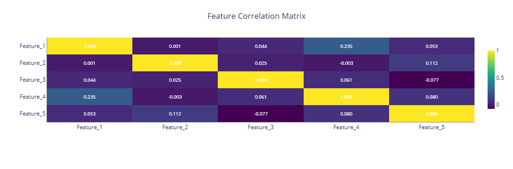

```python
import src.visualisations.plotly_heatmap as HMAP

reload(HMAP)

heatmap = HMAP.PlotlyHeatmap()

heatmap.plot(data=correlation_matrix, plot_title="Feature Correlation Matrix",
             colorscale="viridis", show_values=True, value_format=".3f")
```

### Correlation Matrix

ToC

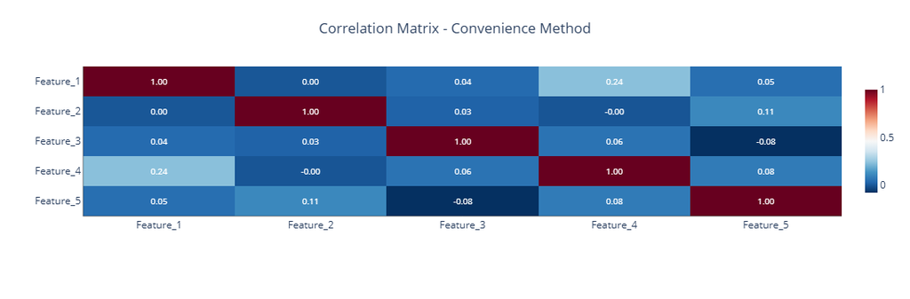

```python
import src.visualisations.plotly_heatmap as HMAP

reload(HMAP)

heatmap = HMAP.PlotlyHeatmap()

heatmap.plot_correlation_matrix(corr_matrix=correlation_matrix,
                                title="Correlation Matrix - Convenience Method",
                                colorscale="coolwarm")
```